# ML_PetProject

ML

В нашем распоряжении - данные по маркетинговым кампаниям банка (источник - https://archive.ics.uci.edu/dataset/222/bank+marketing).  
Наша задача - предсказать, оформит ли клиент срочный депозит, что является задачей классификации.  
План работы следующий:

**1. Данные**

1.1 Базовый анализ данных  
1.2 Разделение на обучающую, валидационную и тестовую выборки  
1.3 Кодирование строковых столбцов  
1.4 Работа с числовыми признаками

**2. Модели**

2.1 Логистическая регрессия  
2.2 Случайный лес  
2.3 Градиентный бустинг XGBoost  
2.4 Градиентный бустинг LightGBM  
2.5 Градиентный бустинг CatBoost

**3. Работа над ошибками**

Так начнём же.

Импортируем библиотеки и установим параметры:

```python
import pandas as pd
import numpy as np
import matplotlib.pyplot as plt
import seaborn as sns
from IPython.display import HTML
import warnings

from sklearn.preprocessing import StandardScaler, MinMaxScaler, RobustScaler, OneHotEncoder
import category_encoders as ce
from sklearn.model_selection import train_test_split, cross_val_score, StratifiedKFold
from sklearn.metrics import classification_report, roc_auc_score, average_precision_score
from imblearn.combine import SMOTETomek
from imblearn.under_sampling import TomekLinks
import optuna

from sklearn.linear_model import LogisticRegression
from sklearn.ensemble import RandomForestClassifier
from xgboost import XGBClassifier
import lightgbm as gbm
import catboost as cb

pd.set_option('max_colwidth',300)
pd.set_option('display.max_columns',None)
%config InlineBackend.figure_format = 'retina'
warnings.filterwarnings('ignore')
p = '<p style="color:#aa88bb">'
```

1. Данные

Загрузим, изучим и подготовим данные к обучению.

1.1 Базовый анализ данных

Откроем csv-файл:

```python
df = pd.read_csv('bank-full.csv',sep=';')
display(df[:5].style.set_table_styles([{'selector':'td:hover','props':'background-color:#aa88bb'}]),\
HTML(p+'Колво строк в датасете: <b>'+str(df.shape[0])[:-3]+' '+str(df.shape[0])[-3:]) )
```

|  | age | job | marital | education | default | balance | housing | loan | contact | day | month | duration | campaign | pdays | previous | poutcome | y |
| --- | --- | --- | --- | --- | --- | --- | --- | --- | --- | --- | --- | --- | --- | --- | --- | --- | --- |
| 0 | 58 | management | married | tertiary | no | 2143 | yes | no | unknown | 5 | may | 261 | 1 | -1 | 0 | unknown | no |
| 1 | 44 | technician | single | secondary | no | 29 | yes | no | unknown | 5 | may | 151 | 1 | -1 | 0 | unknown | no |
| 2 | 33 | entrepreneur | married | secondary | no | 2 | yes | yes | unknown | 5 | may | 76 | 1 | -1 | 0 | unknown | no |
| 3 | 47 | blue-collar | married | unknown | no | 1506 | yes | no | unknown | 5 | may | 92 | 1 | -1 | 0 | unknown | no |
| 4 | 33 | unknown | single | unknown | no | 1 | no | no | unknown | 5 | may | 198 | 1 | -1 | 0 | unknown | no |

Колво строк в датасете: **45 211**

Ознакомимся с общими показателями данных:

```python
print(df.info(), '\n'*3, df.describe())
```

```
<class 'pandas.DataFrame'>
RangeIndex: 45211 entries, 0 to 45210
Data columns (total 17 columns):
 #   Column     Non-Null Count  Dtype
---  ------     --------------  -----
 0   age        45211 non-null  int64
 1   job        45211 non-null  str
 2   marital    45211 non-null  str
 3   education  45211 non-null  str
 4   default    45211 non-null  str
 5   balance    45211 non-null  int64
 6   housing    45211 non-null  str
 7   loan       45211 non-null  str
 8   contact    45211 non-null  str
 9   day        45211 non-null  int64
 10  month      45211 non-null  str
 11  duration   45211 non-null  int64
 12  campaign   45211 non-null  int64
 13  pdays      45211 non-null  int64
 14  previous   45211 non-null  int64
 15  poutcome   45211 non-null  str
 16  y          45211 non-null  str
dtypes: int64(7), str(10)
memory usage: 8.1 MB
None


                 age        balance           day      duration      campaign  \
count  45211.000000   45211.000000  45211.000000  45211.000000  45211.000000
mean      40.936210    1362.272058     15.806419    258.163080      2.763841
std       10.618762    3044.765829      8.322476    257.527812      3.098021
min       18.000000   -8019.000000      1.000000      0.000000      1.000000
25%       33.000000      72.000000      8.000000    103.000000      1.000000
50%       39.000000     448.000000     16.000000    180.000000      2.000000
75%       48.000000    1428.000000     21.000000    319.000000      3.000000
max       95.000000  102127.000000     31.000000   4918.000000     63.000000

              pdays      previous
count  45211.000000  45211.000000
mean      40.197828      0.580323
std      100.128746      2.303441
min       -1.000000      0.000000
25%       -1.000000      0.000000
50%       -1.000000      0.000000
75%       -1.000000      0.000000
max      871.000000    275.000000
```

Как минимум, у нас нет пропусков. Интересно выглядят отрицательные значения в столбце balance, вероятно, это кредиты. Кроме этого, мы видим большое количество строковых значений, и сразу видно, что многие из них бинарны, что упростит их кодирование для ML. С них и начнём - посмотрим общие распределения через классический простой быстрый value_counts():

```python
for i in df.select_dtypes(include='object').columns:
    print(df[i].value_counts(),'\n')
```

```
job
blue-collar      9732
management       9458
technician       7597
admin.           5171
services         4154
retired          2264
self-employed    1579
entrepreneur     1487
unemployed       1303
housemaid        1240
student           938
unknown           288
Name: count, dtype: int64

marital
married     27214
single      12790
divorced     5207
Name: count, dtype: int64

education
secondary    23202
tertiary     13301
primary       6851
unknown       1857
Name: count, dtype: int64

default
no     44396
yes      815
Name: count, dtype: int64

housing
yes    25130
no     20081
Name: count, dtype: int64

loan
no     37967
```

[output cut: 20 more lines]

```
mar      477
dec      214
Name: count, dtype: int64

poutcome
unknown    36959
failure     4901
other       1840
success     1511
Name: count, dtype: int64

y
no     39922
yes     5289
Name: count, dtype: int64
```

Мы видим, что значений во всех столбцах не очень много, что упрощает нам работу. Каких-то явных аномалий тоже нет, кроме значнеия unknown в столбце job - но его мы не будем удалять. Кодирование столбцов отложим до разделения данных, чтобы избежать учтечки, однако уже ясно как мы будем кодировать:  
- столбцы job и month через target-encoding;  
- остальные закодируем через one-hot.  
Для удобства, сразу переименуем столбец y в target:

```python
df = df.rename(columns={'y':'target'})
```

И его всё-таки закодируем в нули и единицы сразу, чтобы потом не усложнять работу и не запутаться:

```python
df['target'] = df['target'].apply(lambda x: 1 if x.lower()=='yes' else 0)
```

Посмотрим на **распределения в столбцах с числовыми значениями**:

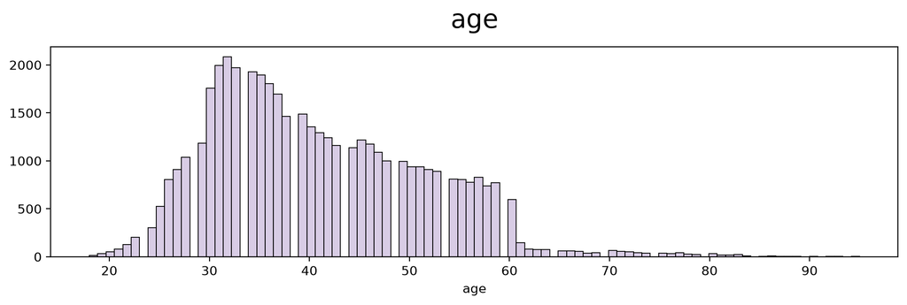

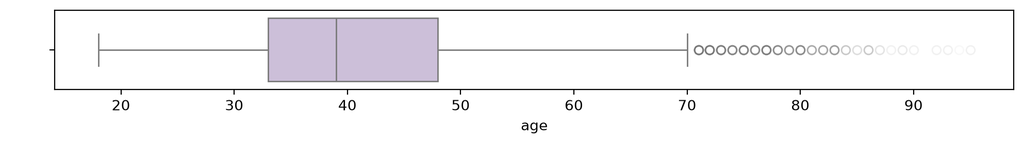

Колво строк с выбросами: **487**

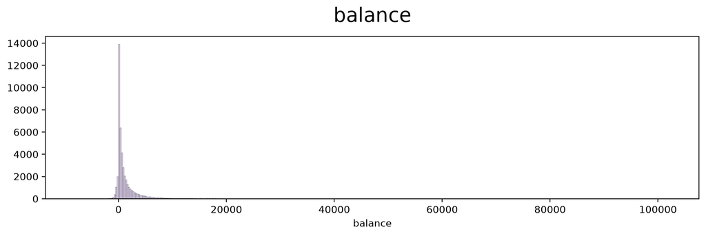

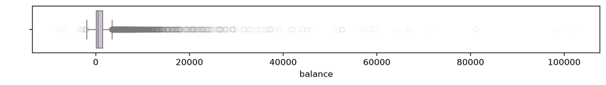

Колво строк с выбросами: **4712**

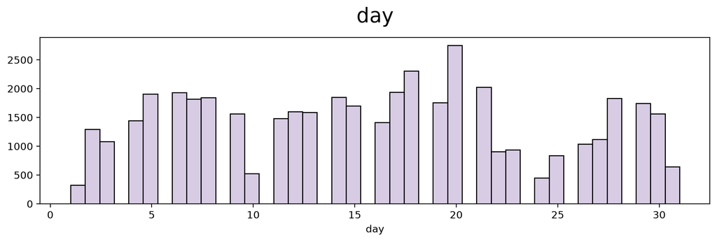

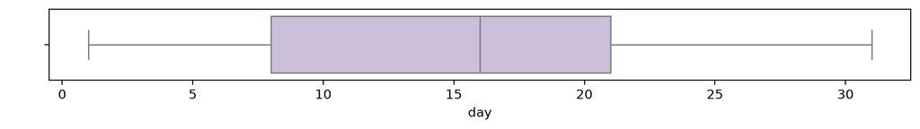

Колво строк с выбросами: **0**

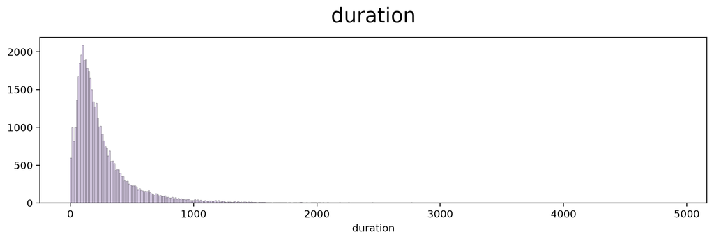

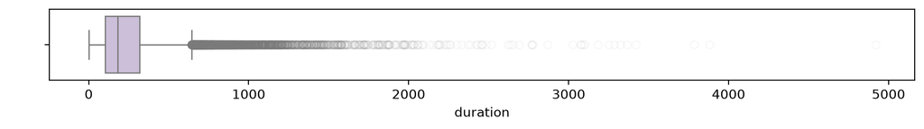

Колво строк с выбросами: **3235**

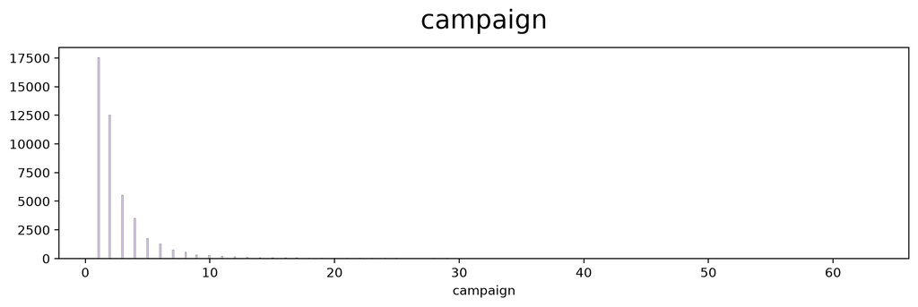

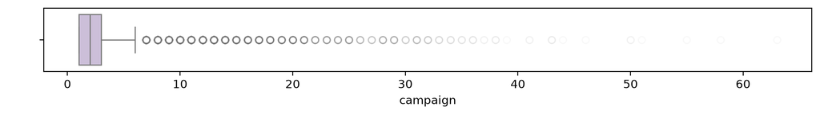

Колво строк с выбросами: **3064**

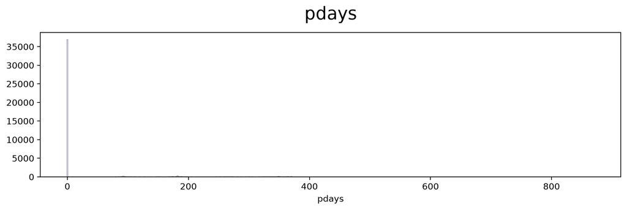

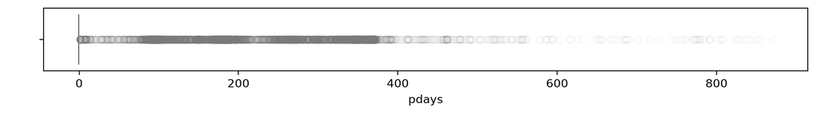

Колво строк с выбросами: **8257**

[4 more figures not shown]

Колво строк с выбросами: **5289**

```python
for i in df.select_dtypes(include='number').columns:
    # Гистограммы
    plt.figure(figsize=(12,3))
    sns.histplot( df[i], color='#ccbbdd' )
    plt.xlabel(i), plt.ylabel(''), plt.title( i, fontsize=20, pad=15 )
    plt.show();

    # Боксплоты
    plt.figure(figsize=(12,1))
    sns.boxplot( x=df[i], color='#ccbbdd', flierprops={'alpha':0.05} )
    plt.ylabel(' ',fontsize=20), plt.show();

    # Для наглядности сразу будем смотреть колво строк более 75 квантиля + полтора межквартильных размаха
    iqrs = df[i].quantile(0.75) + (1.5 * (df[i].quantile(0.75) - df[i].quantile(0.25)))
    display(HTML(p+'Колво строк с выбросами: <b>'+str(df[ df[i] > iqrs ].shape[0])+'</b>'+'<br>'*3))
```

Мы видим в столбце age (возраст) что у нас мало юных клиентов и тех, кому за 60, хотя боксплот показывает их частью "усов", на гистограмме видно, что их всё-таки стоит исключить, но на всякий случай посмотрим:

```python
display(HTML(p+'Колво клиентов моложе 23 и старше 60 лет: <b>'+str(df[ (df['age']<23) | (df['age']>60) ].shape[0])+\
'</b><br>Доля таких клиентов: <b>'+str(round(df[ (df['age']<23) | (df['age']>60) ].shape[0] / df.shape[0] * 100, 2))+'%'))
```

Колво клиентов моложе 23 и старше 60 лет: **1493**  
Доля таких клиентов: **3.3%**

Неоднозначно, потому что целая тысяча клиентов, плюс у старшего поколения обычно как раз есть депозиты - проверим:

```python
df[ (df['age']>60) ]['target'].value_counts()
```

```
target
0    686
1    502
Name: count, dtype: int64
```

Учитывая сильный дисбаланс классов, мы пока не можем убрать 10%. Проверим молодёжь:

```python
df[ (df['age']<23) ]['target'].value_counts()
```

```
target
0    210
1     95
Name: count, dtype: int64
```

Пока примерно 2 к 1, придётся пока что оставить.  
В остальных столбцах всё не так очевидно, тем не менее на графиках мы видим экстремальные значения, поэтому уберём такие, которые явно ненормальны. Для столбца balance это, согласно графику, всё что более 30 000:

```python
df[ (df['balance']>30_000) ]['target'].value_counts()
```

```
target
0    43
1     9
Name: count, dtype: int64
```

Это просто несерьёзно, убираем:

```python
df = df[ (df['balance']<=30_000) ].reset_index(drop=True)
```

Кроме этого, стоит разделить этот столбец на категории, хотя бы по тысячам:

```python
df['balance'] = round(df['balance']/1_000,0)
display(HTML(p+'Колво категорий в столбце balance после деления: <b>'+str(df['balance'].nunique())))
```

Колво категорий в столбце balance после деления: **37**

И заодно сразу посмотрим, нет ли корреляции между балансом, возрастом и таргетом:

```python
df[['balance','age','target']].corr().style.format(precision=2).background_gradient(cmap='BuPu').\
set_table_styles([{'selector':'td:hover','props':'background-color:#aa88bb'}])
```

|  | balance | age | target |
| --- | --- | --- | --- |
| balance | 1.00 | 0.09 | 0.06 |
| age | 0.09 | 1.00 | 0.02 |
| target | 0.06 | 0.02 | 1.00 |

Жаль. Для столбца duration (продолжительность предыдущего звонка в секундах) стоит убрать значения выше 2 100 секунд, их мало:

```python
df = df[ (df['duration']<=2_100) ].reset_index(drop=True)
```

Этот столбец также стоит перевести в минуты:

```python
df['duration'] = round(df['duration']/60,0)
display(HTML(p+'Колво категорий в столбце duration после деления: <b>'+str(df['duration'].nunique())))
```

Колво категорий в столбце duration после деления: **36**

В столбце campaign (колво контактов с клиентом в рамках текущей рекламной компании) есть смысл убрать тех, с кем пришлось контактировать более 20 раз, посомтрим сколько таких клиентов:

```python
display(HTML(p+'Колво клиентов, которым пришлось звонить более 10 раз: <b>'+str(df[ df['campaign']>10 ].shape[0])+\
'</b><br>Колво клиентов, которым пришлось звонить более 20 раз: <b>'+str(df[ df['campaign']>20 ].shape[0])))
```

Колво клиентов, которым пришлось звонить более 10 раз: **1194**  
Колво клиентов, которым пришлось звонить более 20 раз: **243**

Более 10 звонков у нас клиентов многовато, а вот тех, кому звонили больше 20 раз, мы запомним и в следующий раз передадим наиболее хватким продажникам, поскольку крепость, ведущая переговоры наполовину взята. Но сегодня обойдёмся без них:

```python
df = df[ (df['campaign']<=20) ].reset_index(drop=True)
display(HTML(p+'Колво клиентов после отбора: <b>'+\
str(df.shape[0])[:-3]+' '+str(df.shape[0])[-3:]) )
```

Колво клиентов после отбора: **44 871**

Столбец pdays (колво дней после предыдущего звонка клиенту) не так прост как кажется на первый взгляд:

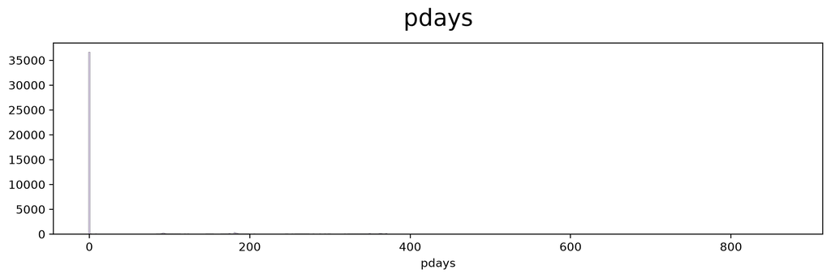

Колво клиентов, которым ранее не звонили: **36624**

```python
q = 'pdays'
plt.figure(figsize=(12,3))
sns.histplot( df[q], color='#ccbbdd' )
plt.xlabel(q), plt.ylabel(''), plt.title( q, fontsize=20, pad=15 )
plt.show();
display(HTML(p+'Колво клиентов, которым ранее не звонили: <b>'+str(df[ df['pdays']<1 ].shape[0])))
```

На графике есть ощущение, что до 400 дней проводилось 2 или 4 кампании, взглянем ближе:

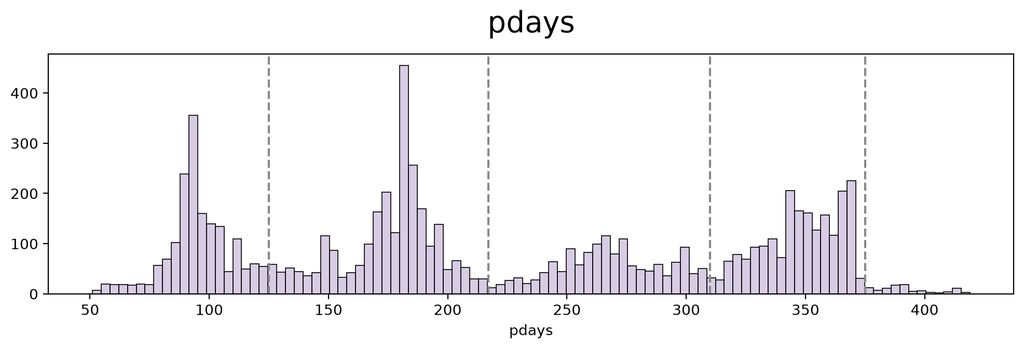

Колво клиентов, которым звонили ранее: **8247**

```python
q = 'pdays'
plt.figure(figsize=(12,3))
sns.histplot( df[ (df[q]>50) & (df[q]<420) ][q], color='#ccbbdd',bins=100 )
plt.xlabel(q), plt.ylabel(''), plt.title( q, fontsize=20, pad=15 )
for i in [125,217,310,375]:
    plt.axvline(x=i,color='#888888',linestyle='--')
plt.show()
display(HTML(p+'Колво клиентов, которым звонили ранее: <b>'+str(df[ df['pdays']>0 ].shape[0])))
```

Похоже, наша догадка верна, выделим 5 категорий  
- Были контакты за последние 125 дней;  
- Были контакты за последние 125-217 дней;  
- Были контакты за последние 225-310 дней;  
- Были контакты за последние 310-375 дней;  
- Остальных отнесём к категории "Ранее не было контактов".

Не будем медлить:

```python
df['pdays'] = df['pdays'].apply(lambda x: 1 if (x>0 and x<=125) else\
                                          2 if (x>125 and x<=217) else\
                                          3 if (x>225 and x<=310) else\
                                          4 if (x>310 and x<=375) else 0)
df['pdays'].value_counts()
```

```
pdays
0    36971
2     2537
4     2019
1     1958
3     1386
Name: count, dtype: int64
```

И сразу поделим его аналогично one-hot, так как у нас не много ни категорий, ни данных.  
Сделаем это красиво - через pd.get_dummies внутри горизонтального конката с дропом столбца:

```python
df = pd.concat([ df, pd.get_dummies(df['pdays'],prefix='pdays',dtype=int) ],axis=1).drop('pdays',axis=1)
df[:2].style.set_table_styles([{'selector':'td:hover','props':'background-color:#aa88bb'}])
```

|  | age | job | marital | education | default | balance | housing | loan | contact | day | month | duration | campaign | previous | poutcome | target | pdays_0 | pdays_1 | pdays_2 | pdays_3 | pdays_4 |
| --- | --- | --- | --- | --- | --- | --- | --- | --- | --- | --- | --- | --- | --- | --- | --- | --- | --- | --- | --- | --- | --- |
| 0 | 58 | management | married | tertiary | no | 2.000000 | yes | no | unknown | 5 | may | 4.000000 | 1 | 0 | unknown | 0 | 1 | 0 | 0 | 0 | 0 |
| 1 | 44 | technician | single | secondary | no | 0.000000 | yes | no | unknown | 5 | may | 3.000000 | 1 | 0 | unknown | 0 | 1 | 0 | 0 | 0 | 0 |

Последний столбец этой группы связан с предыдущим - previous показывает колво контактов с данным клиентом в рамках предыдущей рекламной компании:

```python
display(HTML(p+'Колво клиентов, которым ранее звонили более 10 раз: <b>'+str(df[ df['previous']>10 ].shape[0])+\
'</b><br>Колво клиентов, которым ранее звонили более 20 раз: <b>'+str(df[ df['previous']>20 ].shape[0])))
```

Колво клиентов, которым ранее звонили более 10 раз: **294**  
Колво клиентов, которым ранее звонили более 20 раз: **55**

Так же, как и ранее, отложим некоторых до следующего обзвона, чтобы проверить на них класс наших топовых продажников:

```python
df = df[ (df['previous']<=20) ].reset_index(drop=True)
```

1.2 Разделение на обучающую, валидационную и тестовую выборки

Разделим данные в пропорциях 66 на 34 как компромисс между количеством данных для обучения, настройки и проверки:

```python
X = df.drop('target',axis=1)
y = df['target']

X_train, X_test, y_train, y_test = train_test_split(X, y, test_size=0.34, random_state=44, stratify=y)
```

С одной стороны, было бы верно использовать переменные temp вместо test, но здесь мы перезаписываем переменные test для экономии оперативной памяти.  
Вторую выборку, в свою очередь, разделим на валидационную и тестовую в равных пропорциях:

```python
X_val, X_test, y_val, y_test = train_test_split(X_test, y_test, test_size=0.5, random_state=33, stratify=y_test)
```

Проверим, что целевая переменная праспределена примерно поровну во всех трёх выборках:

```python
for i in [y_train, y_val, y_test]:
    print(i.value_counts(normalize=True),'\n')
```

```
target
0    0.88292
1    0.11708
Name: proportion, dtype: float64

target
0    0.882924
1    0.117076
Name: proportion, dtype: float64

target
0    0.882924
1    0.117076
Name: proportion, dtype: float64
```

Поделено всё верно, но у нас очень сильный дисбаланс классов, запомним это.

1.3 Кодирование строковых признаков

Ранее мы договорились, что будем кодировать данные следующим образом:  
- столбцы job и month через target-encoding;  
- остальные закодируем через one-hot.  
Начём с первых двух. Определим энкодер, обучим его только на тренировочных данных (во избежание утечки), и затем применим к валидационным и тестовым:

```python
encoder = ce.TargetEncoder(cols=['job','month'], smoothing=20, min_samples_leaf=10)

X_train = encoder.fit_transform(X_train, y_train)
X_val = encoder.transform(X_val)
X_test = encoder.transform(X_test)

display(X_train[:3].style.set_properties(**{'background-color':'#aa88bb'},subset=['job','month']).\
set_table_styles([{'selector':'td:hover','props':'background-color:#ddbbff'}]))
```

|  | age | job | marital | education | default | balance | housing | loan | contact | day | month | duration | campaign | previous | poutcome | pdays_0 | pdays_1 | pdays_2 | pdays_3 | pdays_4 |
| --- | --- | --- | --- | --- | --- | --- | --- | --- | --- | --- | --- | --- | --- | --- | --- | --- | --- | --- | --- | --- |
| 41234 | 25 | 0.131536 | single | tertiary | no | 1.000000 | no | no | cellular | 18 | 0.470588 | 4.000000 | 2 | 2 | failure | 0 | 1 | 0 | 0 | 0 |
| 43612 | 30 | 0.074138 | single | primary | no | 0.000000 | no | no | unknown | 26 | 0.104529 | 0.000000 | 1 | 0 | unknown | 1 | 0 | 0 | 0 | 0 |
| 44754 | 38 | 0.110448 | married | tertiary | no | 0.000000 | no | no | cellular | 8 | 0.097206 | 5.000000 | 2 | 4 | success | 0 | 0 | 1 | 0 | 0 |

Как видим, всё закодировалось. Для остальных нам подойдёт one-hot. Чтобы не нагромождать кучу кода, создадим фукнцию:

```python
encoder = OneHotEncoder(drop='first', sparse_output=False, handle_unknown='ignore')
str_cols = X_train.select_dtypes(include='object').columns

encoder.fit(X_train[str_cols])

def encode_my_data_baby(data):
    # Вернём датасет, из которого убрали строковые столбцы
    return pd.concat([data.drop(str_cols,axis=1),\
    # и к которому горизонтально конкатим новый датасет, из закодированных признаков
    pd.DataFrame(encoder.transform(data[str_cols]), columns=encoder.get_feature_names_out(str_cols), index=data.index)], axis=1)

X_train = encode_my_data_baby(X_train)
X_val = encode_my_data_baby(X_val)
X_test = encode_my_data_baby(X_test)

display(X_val[:3].style.set_table_styles([{'selector':'td:hover','props':'background-color:#ddbbff'}]))
```

|  | age | job | balance | day | month | duration | campaign | previous | pdays_0 | pdays_1 | pdays_2 | pdays_3 | pdays_4 | marital_married | marital_single | education_secondary | education_tertiary | education_unknown | default_yes | housing_yes | loan_yes | contact_telephone | contact_unknown | poutcome_other | poutcome_success | poutcome_unknown |
| --- | --- | --- | --- | --- | --- | --- | --- | --- | --- | --- | --- | --- | --- | --- | --- | --- | --- | --- | --- | --- | --- | --- | --- | --- | --- | --- |
| 39191 | 29 | 0.092786 | 1.000000 | 26 | 0.066542 | 6.000000 | 1 | 0 | 1 | 0 | 0 | 0 | 0 | 0.000000 | 1.000000 | 1.000000 | 0.000000 | 0.000000 | 0.000000 | 0.000000 | 0.000000 | 0.000000 | 0.000000 | 0.000000 | 0.000000 | 1.000000 |
| 27950 | 35 | 0.094027 | 1.000000 | 29 | 0.104235 | 6.000000 | 1 | 0 | 1 | 0 | 0 | 0 | 0 | 1.000000 | 0.000000 | 1.000000 | 0.000000 | 0.000000 | 0.000000 | 1.000000 | 0.000000 | 0.000000 | 0.000000 | 0.000000 | 0.000000 | 1.000000 |
| 27835 | 43 | 0.110448 | 0.000000 | 29 | 0.104235 | 4.000000 | 1 | 0 | 1 | 0 | 0 | 0 | 0 | 1.000000 | 0.000000 | 1.000000 | 0.000000 | 0.000000 | 0.000000 | 0.000000 | 0.000000 | 1.000000 | 0.000000 | 0.000000 | 0.000000 | 1.000000 |

Отлично.

1.4 Работа с числовыми признаками

С бинарными признаками нам возиться ни к чему, а с остальными нужно поработать, потому что многие модели зависят от масштаба признаков, поэтому приведём данные к значениям от нуля до единицы. Именно этот интервал нам важен потому, что после one-hot у нас много столбцов со значениями 0 и 1.  
Ещё раз посмотрим на графики:

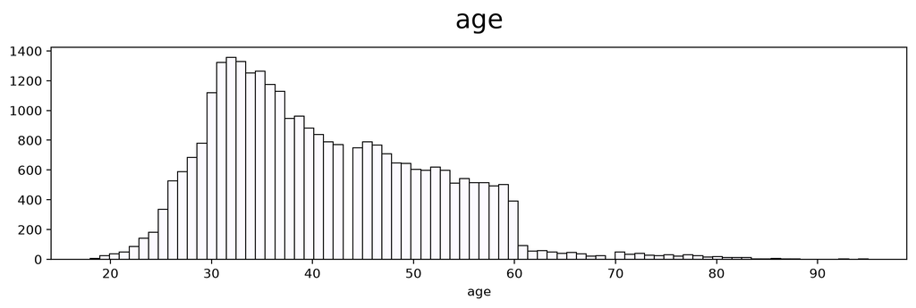

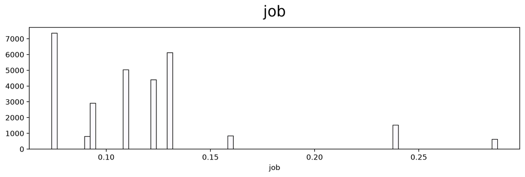

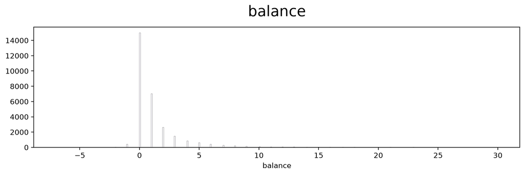

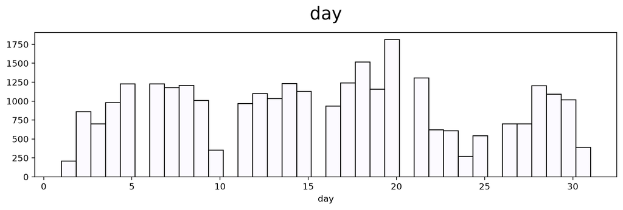

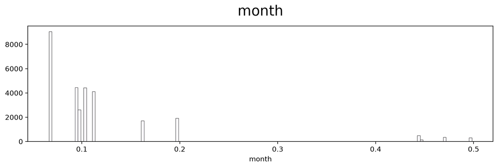

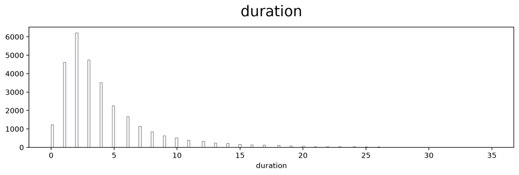

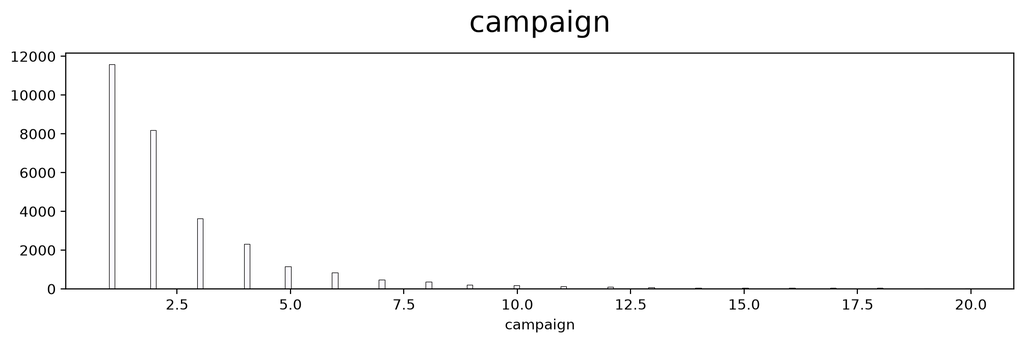

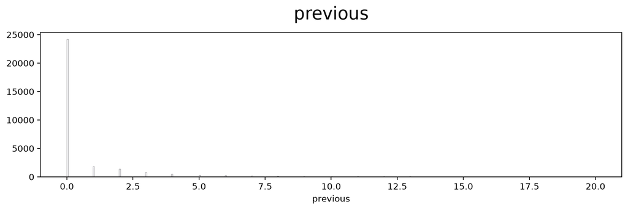

```python
for a in [b for b in X_train.columns if '_' not in b]:
    plt.figure(figsize=(12,3))
    sns.histplot( X_train[a], color='#fcf9ff' )
    plt.xlabel(a), plt.ylabel(''), plt.title( a, fontsize=20, pad=15 )
    plt.show();
```

Учитывая, что нам нужно создать диапазоны от 0 до 1, то для всех нам подойдёт MinMaxScaler:

```python
min_nax_cols = [b for b in X_train.columns if ('_' not in b) and ('pdays' not in b)]

scaler = MinMaxScaler()
scaler.fit(X_train[min_nax_cols])

X_train[min_nax_cols] = scaler.transform(X_train[min_nax_cols])
X_val[min_nax_cols] = scaler.transform(X_val[min_nax_cols])
X_test[min_nax_cols] = scaler.transform(X_test[min_nax_cols])
```

И ещё раз взглянем на таблицу:

```python
display(X_train[-3:].style.set_table_styles([{'selector':'td:hover','props':'background-color:#ddbbff'}]))
```

|  | age | job | balance | day | month | duration | campaign | previous | pdays_0 | pdays_1 | pdays_2 | pdays_3 | pdays_4 | marital_married | marital_single | education_secondary | education_tertiary | education_unknown | default_yes | housing_yes | loan_yes | contact_telephone | contact_unknown | poutcome_other | poutcome_success | poutcome_unknown |
| --- | --- | --- | --- | --- | --- | --- | --- | --- | --- | --- | --- | --- | --- | --- | --- | --- | --- | --- | --- | --- | --- | --- | --- | --- | --- | --- |
| 43428 | 0.181818 | 0.269682 | 0.189189 | 0.866667 | 0.000000 | 0.000000 | 0.000000 | 0.000000 | 1 | 0 | 0 | 0 | 0 | 1.000000 | 0.000000 | 0.000000 | 1.000000 | 0.000000 | 0.000000 | 1.000000 | 0.000000 | 0.000000 | 1.000000 | 0.000000 | 0.000000 | 1.000000 |
| 40452 | 0.207792 | 0.001393 | 0.243243 | 0.333333 | 0.105518 | 0.085714 | 0.000000 | 0.000000 | 1 | 0 | 0 | 0 | 0 | 0.000000 | 1.000000 | 1.000000 | 0.000000 | 0.000000 | 0.000000 | 0.000000 | 0.000000 | 0.000000 | 0.000000 | 0.000000 | 0.000000 | 1.000000 |
| 37577 | 0.441558 | 0.171113 | 0.189189 | 0.433333 | 0.000000 | 0.028571 | 0.052632 | 0.500000 | 0 | 0 | 0 | 1 | 0 | 1.000000 | 0.000000 | 0.000000 | 1.000000 | 0.000000 | 0.000000 | 1.000000 | 0.000000 | 1.000000 | 0.000000 | 1.000000 | 0.000000 | 0.000000 |

Данные подготовлены, перейдём непосредственно к обучению.

2. Модели

Так как мы решаем задачу классификации, то сравним несколько подходящих моделей для этого. Для каждой модели подберём гиперпараметры с помощью optuna, затем обучим модели, сделаем предсказания и оценим метрики, и в итоге выберем наиболее подходяшую модель.  
Вспомним, что нашей задачей является предсказать, оформит ли клиент срочный депозит.

2.1 Логистическая регрессия

Начнём подбора гиперпараметров, используя optuna, причём, максимально удобно - с распаковкой словарей:

```python
%%time
cv = StratifiedKFold(n_splits=5, shuffle=True, random_state=44)

def objective(trial):

    param = {'C': trial.suggest_float('C', 0.001, 10, log=True), # Сила регуляризации лог.рег.
             'max_iter': trial.suggest_int('max_iter', 500, 2000) } # Кол-во итераций

    model = LogisticRegression( **param, solver='lbfgs', penalty='l2', class_weight='balanced', random_state=44 ) # Обучаем модель
    scores = cross_val_score(model, X_train, y_train, cv=cv, scoring='f1') # Проводим кросс-валидацию
    return scores.mean()

study = optuna.create_study(direction='maximize', sampler=optuna.samplers.TPESampler(seed=44))
study.optimize(objective, n_trials=50, show_progress_bar=True)
```

Отлично, достанем наилучшие параметры, обучим модель Логистической регрессии с их применением, но предсказывать будем именно вероятность, чтобы выбрать те данные, в которых модель наиболее уверена:

```python
model = LogisticRegression( **study.best_params, solver='lbfgs', class_weight='balanced', random_state=44 )

model.fit(X_train, y_train)
y_pred = model.predict_proba(X_val)[:, 1]
```

Для дальнейшего удобства определим функцию для проверки лучших гиперпараметров и важности признаков:

```python
def model_check(check_method):
    return display( pd.concat([ pd.DataFrame([study.best_params]).T.reset_index().rename(columns={'index':'Гиперпараметр',0:'Значение ГП'}),\
                    pd.DataFrame({'Признак':X_train.columns,'Значимость признака':check_method}).\
                    sort_values('Значимость признака',ascending=False).reset_index(drop=True)[:5],\
                    pd.DataFrame(classification_report(y_val, y_pred_high_risk, output_dict=True)).T.\
                    reset_index().rename(columns={'index':'Показатель'}) ],axis=1).\
                    style.format(precision=2,na_rep='').background_gradient(subset=['Значимость признака'],cmap='BuPu').\
                    background_gradient(subset=['precision','recall','f1-score'],cmap='Purples',vmin=0.2).\
                    set_table_styles([{'selector':'td:hover','props':[('font-size','30px')]}]) )
```

Выберем тех клиентов, в ком модель уверена более чем на 50%:

```python
y_pred_high_risk = (y_pred >= 0.5).astype(int)
```

И посмотрим результаты, и заодно сразу определим функцию для их быстрого просмотра:

```python
model_check( model.coef_.ravel() )
```

[output not shown]

```python
y_pred_high_risk = (y_pred >= 0.1).astype(int)
model_check( model.coef_.ravel() )
```

```python
y_pred_high_risk = (y_pred >= 0.6).astype(int)
model_check( model.coef_.ravel() )
```

```python
model = LogisticRegression( C=10, max_iter=6000, penalty='l2', solver='lbfgs', class_weight='balanced', random_state=44 )

model.fit(X_train, y_train)
y_pred = model.predict_proba(X_val)[:, 1]
y_pred_high_risk = (y_pred >= 0.3).astype(int)

model_check( model.coef_.ravel() )
```

Попробуем более радикальные изменения, заменим Solver:

```python
model = LogisticRegression( C=0.5, max_iter=2000, penalty='l1', solver='saga', class_weight='balanced', random_state=44 )

model.fit(X_train, y_train)
y_pred = model.predict_proba(X_val)[:, 1]
y_pred_high_risk = (y_pred >= 0.3).astype(int)

model_check( model.coef_.ravel() )
```

```python
model = LogisticRegression( C=0.01, max_iter=2000, penalty='l2', solver='newton-cg', class_weight='balanced', random_state=44 )

model.fit(X_train, y_train)
y_pred = model.predict_proba(X_val)[:, 1]
y_pred_high_risk = (y_pred >= 0.3).astype(int)

model_check( model.coef_.ravel() )
```

В итоге мы перебрали разные варианты логистической регрессии, пришло время двигаться дальше.

2.2 Случайный лес

Запустим подбор гиперпараметров:

```python
%%time
cv = StratifiedKFold(n_splits=5, shuffle=True, random_state=44)

def objective(trial):

    param = {'n_estimators': trial.suggest_int('n_estimators', 100, 500), # Количество деревьев
             'max_depth': trial.suggest_int('max_depth', 5, 30),  # Максимальная глубина дерева
             'min_samples_split': trial.suggest_int('min_samples_split', 2, 20), # Минимальное число образцов узла
             'min_samples_leaf': trial.suggest_int('min_samples_leaf', 1, 10)} # Минимальное число образцов в листе

    model = RandomForestClassifier(**param, class_weight='balanced', random_state=44) # Обучаем модель
    scores = cross_val_score(model, X_train, y_train, cv=cv, scoring='f1') # Проводим кросс-валидацию
    return scores.mean()

study = optuna.create_study(direction='maximize', sampler=optuna.samplers.TPESampler(seed=44))
study.optimize(objective, n_trials=50, show_progress_bar=True)
```

Обучим модель на лучших параметрах и посмотрим результаты:

```python
model = RandomForestClassifier( **study.best_params, class_weight='balanced', random_state=44 )

model.fit(X_train, y_train)
y_pred = model.predict_proba(X_val)[:, 1]
model_check( model.feature_importances_ )
```

Выберем клиентов, в ком модель уверена более чем на 50%, и сразу проверим метрики:

```python
y_pred_high_risk = (y_pred >= 0.5).astype(int)
model_check( model.feature_importances_ )
```

```python
y_pred_high_risk = (y_pred >= 0.1).astype(int)
model_check( model.feature_importances_ )
```

```python
y_pred_high_risk = (y_pred >= 0.66).astype(int)
model_check( model.feature_importances_ )
```

Снова придётся поколдовать. Попробуем увеличить глубину деревьев:

```python
model = RandomForestClassifier( n_estimators=387,
                                max_depth=50, # Увеличим с 24 до 50
                                min_samples_split=6,
                                min_samples_leaf=3,
                                class_weight='balanced', random_state=44 )

model.fit(X_train, y_train)
y_pred = model.predict_proba(X_val)[:, 1]
y_pred_high_risk = (y_pred >= 0.5).astype(int)

model_check( model.feature_importances_ )
```

```python
model = RandomForestClassifier( n_estimators=387,
                                max_depth=50,
                                min_samples_split=12, # Повысим вдвое
                                min_samples_leaf=6, # Повысим вдвое
                                class_weight='balanced', random_state=44 )

model.fit(X_train, y_train)
y_pred = model.predict_proba(X_val)[:, 1]
y_pred_high_risk = (y_pred >= 0.5).astype(int)

model_check( model.feature_importances_ )
```

```python
model = RandomForestClassifier( n_estimators=777, # Повысим примерно в два раза
                                max_depth=50,
                                min_samples_split=12,
                                min_samples_leaf=6,
                                class_weight='balanced', random_state=44 )

model.fit(X_train, y_train)
y_pred = model.predict_proba(X_val)[:, 1]
y_pred_high_risk = (y_pred >= 0.5).astype(int)

model_check( model.feature_importances_ )
```

```python
y_pred_high_risk = (y_pred >= 0.6).astype(int)
model_check( model.feature_importances_ )
```

2.3 Градиентный бустинг XGBoost

Подберём наилучшие гиперпараметры:

```python
%%time
cv = StratifiedKFold(n_splits=5, shuffle=True, random_state=44)

def objective(trial):

    param = {'max_depth': trial.suggest_int('max_depth', 3, 10),
             'learning_rate': trial.suggest_float('learning_rate', 0.01, 0.3, log=True), # Осторожность обновления прогнозов
             'subsample': trial.suggest_float('subsample', 0.6, 1.0), # Доля объектов для каждого дерева
             'colsample_bytree': trial.suggest_float('colsample_bytree', 0.6, 1.0), # Доля признаков
             'min_child_weight': trial.suggest_int('min_child_weight', 1, 10)} # Аналог min_samples_leaf для бустинга

    model = XGBClassifier(**param, n_estimators=1_000, eval_metric='logloss',\
                          class_weight='balanced', use_label_encoder=False, random_state=44, n_jobs=5)
    scores = cross_val_score(model, X_train, y_train, cv=cv, scoring='f1')
    return scores.mean()

study = optuna.create_study(direction='maximize', sampler=optuna.samplers.TPESampler(seed=44))
study.optimize(objective, n_trials=50, show_progress_bar=True)
```

Обучим модель на лучших параметрах и посмотрим результаты:

```python
model = XGBClassifier( **study.best_params, n_estimators=1_000, eval_metric='logloss',\
                       class_weight='balanced', use_label_encoder=False, random_state=44, n_jobs=5)

model.fit(X_train, y_train)
y_pred = model.predict_proba(X_val)[:, 1]
y_pred_high_risk = (y_pred >= 0.5).astype(int)

model_check( model.feature_importances_ )
```

Немного снизим порог уверенности модели:

```python
y_pred_high_risk = (y_pred >= 0.4).astype(int)
model_check( model.feature_importances_ )
```

```python
for i in [10, 20, 30]:
    display(HTML(p+'<br>Глубина деревьев: '+str(i)))
    model = XGBClassifier( max_depth=i,
                           learning_rate=0.014738832258817813,
                           subsample=0.734,
                           colsample_bytree=0.919,
                           min_child_weight=9,
                           n_estimators=1000,
                           eval_metric='logloss',
                           use_label_encoder=False,
                           class_weight='balanced', random_state=44, n_jobs=5 )
    model.fit(X_train, y_train)
    y_pred = model.predict_proba(X_val)[:, 1]
    y_pred_high_risk = (y_pred >= 0.4).astype(int)
    model_check( model.feature_importances_ )
```

```python
for i in [0.001, 0.1, 0.5]:
    display(HTML(p+'<br>learning rate: '+str(i)))
    model = XGBClassifier( max_depth=20,
                           learning_rate=i,
                           subsample=0.734,
                           colsample_bytree=0.919,
                           min_child_weight=9,
                           n_estimators=1000,
                           eval_metric='logloss',
                           use_label_encoder=False,
                           class_weight='balanced', random_state=44, n_jobs=5 )
    model.fit(X_train, y_train)
    y_pred = model.predict_proba(X_val)[:, 1]
    y_pred_high_risk = (y_pred >= 0.4).astype(int)
    model_check( model.feature_importances_ )
```

```python
for i in [0.6, 0.8, 1.0]:
    display(HTML(p+'<br>subsample: '+str(i)))
    model = XGBClassifier( max_depth=20,
                           learning_rate=0.014738832258817813,
                           subsample=i,
                           colsample_bytree=0.919,
                           min_child_weight=9,
                           n_estimators=1000,
                           eval_metric='logloss',
                           use_label_encoder=False,
                           class_weight='balanced', random_state=44, n_jobs=5 )
    model.fit(X_train, y_train)
    y_pred = model.predict_proba(X_val)[:, 1]
    y_pred_high_risk = (y_pred >= 0.4).astype(int)
    model_check( model.feature_importances_ )
```

2.4 Градиентный бустинг LightGBM

Запустим Optuna:

```python
%%time
cv = StratifiedKFold(n_splits=5, shuffle=True, random_state=44)

def objective(trial):

    param = {'max_depth': trial.suggest_int('max_depth', 3, 20),
             'learning_rate': trial.suggest_float('learning_rate', 0.01, 0.3, log=True),
             'subsample': trial.suggest_float('subsample', 0.6, 1.0),
             'colsample_bytree': trial.suggest_float('colsample_bytree', 0.6, 1.0),
             'min_child_samples': trial.suggest_int('min_child_samples', 5, 30),
             'reg_alpha': trial.suggest_float('reg_alpha', 0.001, 10.0, log=True),
             'reg_lambda': trial.suggest_float('reg_lambda', 0.001, 10.0, log=True) }

    model = gbm.LGBMClassifier(**param, n_estimators=1_000, class_weight='balanced', random_state=44, n_jobs=5, verbose=-1)
    scores = cross_val_score(model, X_train, y_train, cv=cv, scoring='f1')
    return scores.mean()

study = optuna.create_study(direction='maximize', sampler=optuna.samplers.TPESampler(seed=44))
study.optimize(objective, n_trials=50, show_progress_bar=True)
```

Обучим модель на лучших гиперпараметрах:

```python
model = gbm.LGBMClassifier( **study.best_params, n_estimators=1_000, class_weight='balanced', random_state=44, n_jobs=5, verbose=-1)

model.fit(X_train, y_train)
y_pred = model.predict_proba(X_val)[:, 1]
y_pred_high_risk = (y_pred >= 0.5).astype(int)
model_check( model.feature_importances_ )
```

Взглянем на показатели при большей и при меньшей уверенности модели:

```python
y_pred_high_risk = (y_pred >= 0.6).astype(int)
model_check( model.feature_importances_ )
y_pred_high_risk = (y_pred >= 0.4).astype(int)
model_check( model.feature_importances_ )
```

2.5 Градиентный бустинг Catboost

Подберём наилучшие гиперпараметры:

```python
%%time
cv = StratifiedKFold(n_splits=5, shuffle=True, random_state=44)

def objective(trial):
    param = {'depth': trial.suggest_int('depth', 3, 9),
             'learning_rate': trial.suggest_float('learning_rate', 0.01, 0.3, log=True),
             'l2_leaf_reg': trial.suggest_float('l2_leaf_reg', 0.001, 10.0, log=True), # аналог регуляризации
             'bagging_temperature': trial.suggest_float('bagging_temperature', 0.0, 1.0),
             'random_strength': trial.suggest_float('random_strength', 0.0, 2.0)} # шум для устойчивости

    model = cb.CatBoostClassifier(**param, iterations=1_000, auto_class_weights='Balanced',\
                                  early_stopping_rounds=50, random_state=44, thread_count=5, verbose=False)
    scores = cross_val_score(model, X_train, y_train, cv=cv, scoring='f1')
    return scores.mean()

study = optuna.create_study(direction='maximize', sampler=optuna.samplers.TPESampler(seed=44))
study.optimize(objective, n_trials=30, show_progress_bar=True)
```

Попробуем лучшие значения:

```python
model = cb.CatBoostClassifier(**study.best_params, random_state=44, auto_class_weights='Balanced', thread_count=5, verbose=False)

model.fit(X_train, y_train)
y_pred = model.predict_proba(X_val)[:, 1]
y_pred_high_risk = (y_pred >= 0.5).astype(int)
model_check( model.feature_importances_ )
```

Поиграем с уверенностью:

```python
y_pred_high_risk = (y_pred >= 0.6).astype(int)
model_check( model.feature_importances_ )
y_pred_high_risk = (y_pred >= 0.4).astype(int)
model_check( model.feature_importances_ )
```

3. Работа над ошибками

Переработаем наши данные и постараемся исправить положение.

3.1 Создание дополнительных признаков

Ещё раз взглянем на таблицу:

```python
df[-3:].style.set_table_styles([{'selector':'td:hover','props':'background-color:#aa88bb'}])
```

Пройдём по очереди по всем столбцам, начиная с возраста, который разделим на категории:

```python
plt.figure(figsize=(12,3))
sns.histplot( df['age'], color='#f0fff5', bins=df['age'].nunique() )
plt.xlabel('age'), plt.ylabel(''), plt.title( 'age', fontsize=20, pad=15 )
plt.show();
```

[output not shown]

Кроме клиентов до 30 лет, сложно выделить какие-то явные группы, поэтому создадим 4:

```python
df['age_group'] = df['age'].apply(lambda x: 1 if (x<30) else 2 if (x>=30 and x<45) else 3 if (x>=45 and x<61) else 4)
df = pd.concat([ df, pd.get_dummies(df['age_group'],prefix='age_group',dtype=int) ],axis=1).drop('age_group',axis=1)
display(df[:2].style.set_table_styles([{'selector':'td:hover','props':'background-color:#aa88bb'}]))
```

Помимо этого, нам нужно создать дополнительные признаки поведения клиентов, помогающие различать клиентов по их поведению:

1. Отношение баланса на один контакт в рамках текущей кампании;
2. Отношение баланса к длительности разговора;
3. Средняя продолжительность разговора.

Всё просто: клиент с большим балансом, но 10 контактами и короткой беседой — это другой профиль, чем клиент с тем же балансом и 1–2 длинными разговорами

```python
df['balance_per_contact'] = df['balance'] / (df['campaign']+1)
df['balance_per_duration'] = df['balance'] / (df['duration']+1)
df['duration_per_contact'] = df['duration'] / (df['campaign']+1)
```

Учитывая, что у нас сильно скошен столбец с балансом, мы попробуем логарифмирование, предварительно заменив отрицательные значения на нули, тк эта инфо у нас и так продублирована в столбце loan:

```python
plt.figure(figsize=(12,3))
sns.histplot( df['balance'], color='#f5f0ff', bins=df['balance'].nunique() )
plt.xlabel('balance'), plt.ylabel(''), plt.title( 'balance', fontsize=20, pad=15 )
plt.show();

df.loc[df['balance'] < 0, 'balance'] = 0
df['balance'] = np.log1p(df['balance'])
```

Проверить есть ли слабые бестолковые признаки

Но самое главное - у нас много клиентов, по которым нет информации об успешности предыдущих взаимодействий. Преположим, что если у них ещё и нулевой таргет - то это просто шум в наших данных:

```python
df = df[ ((df['poutcome']!='unknown') & (df['poutcome']!='other')) | (df['target']!=0) ].reset_index(drop=True)
```

```python
df = df[ (df['poutcome']!='unknown') & (df['poutcome']!='other') ].reset_index(drop=True)
```

```python
df = df.drop(['month','day','job'],axis=1)
```

Снова разделим и закодируем данные:

```python
# Рзделим данные
X = df.drop('target',axis=1)
y = df['target']
X_train, X_test, y_train, y_test = train_test_split(X, y, test_size=0.34, random_state=44, stratify=y)
X_val, X_test, y_val, y_test = train_test_split(X_test, y_test, test_size=0.5, random_state=33, stratify=y_test)

# Закодируем таргет энкодером столбцы job и month
encoder = ce.TargetEncoder(cols=['month','job'], smoothing=20, min_samples_leaf=10)
X_train = encoder.fit_transform(X_train, y_train)
X_val = encoder.transform(X_val)
X_test = encoder.transform(X_test)

# Закодируем через one-hot столлбцы типа object
encoder = OneHotEncoder(drop='first', sparse_output=False, handle_unknown='ignore')
str_cols = X_train.select_dtypes(include='object').columns
encoder.fit(X_train[str_cols])
X_train = encode_my_data_baby(X_train)
X_val = encode_my_data_baby(X_val)
X_test = encode_my_data_baby(X_test)

# Применим MinMaxScaler к числовым столбцам
min_nax_cols = [b for b in X_train.columns if ('_' not in b) and ('pdays' not in b)]
scaler = MinMaxScaler()
scaler.fit(X_train[min_nax_cols])
X_train[min_nax_cols] = scaler.transform(X_train[min_nax_cols])
X_val[min_nax_cols] = scaler.transform(X_val[min_nax_cols])
X_test[min_nax_cols] = scaler.transform(X_test[min_nax_cols])
```

Теперь посмотрим, нет ли у нас мультиколлинеарности признаков, предварительно переместив целевую перемнную на первое место для удобства:

```python
heat = pd.concat([y_train,X_train],axis=1).drop('previous',axis=1).corr()*100

plt.figure(figsize=(18, 10))
ax = sns.heatmap(data=heat, annot=True, fmt='.0f', annot_kws={'size':8}, vmin=-70, vmax=70,\
cmap='Purples', cbar=False, linewidth=0.5, linecolor='#ffffff', square = True)
plt.title('Хитмеп', fontsize=20, pad=15)
plt.tick_params(axis='both', labelsize=10, left=False, bottom=False)
plt.tight_layout()
```

[output not shown]

Убираем ли возраст?

Может убрать неэффективные месяцы и посмотреть на остальных?

3.2 Овер- и андерсемплинг

Одна из главных проблем - сильный дисбаланс классов:

```python
df['target'].value_counts()
```

```python
df['target'].value_counts(normalize=True)
```

```python
%%time
cv = StratifiedKFold(n_splits=5, shuffle=True, random_state=44)

def objective(trial):
    param = {'depth': trial.suggest_int('depth', 3, 9),
             'learning_rate': trial.suggest_float('learning_rate', 0.01, 0.3, log=True),
             'l2_leaf_reg': trial.suggest_float('l2_leaf_reg', 0.001, 10.0, log=True), # аналог регуляризации
             'bagging_temperature': trial.suggest_float('bagging_temperature', 0.0, 1.0),
             'random_strength': trial.suggest_float('random_strength', 0.0, 2.0)} # шум для устойчивости

    model = cb.CatBoostClassifier(**param, iterations=1_000, auto_class_weights='Balanced',\
                                  early_stopping_rounds=50, random_state=44, thread_count=5, verbose=False)
    scores = cross_val_score(model,X_train, y_train, cv=cv, scoring='f1')
    return scores.mean()

study = optuna.create_study(direction='maximize', sampler=optuna.samplers.TPESampler(seed=44))
study.optimize(objective, n_trials=5, show_progress_bar=True)

model = cb.CatBoostClassifier(**study.best_params, iterations=1_000, auto_class_weights='Balanced',\
                              early_stopping_rounds=50, random_state=44, thread_count=5, verbose=False)
model.fit(X_train, y_train)
y_pred = model.predict_proba(X_val)[:, 1]

for i in [0.1,0.4,0.5,0.7]:
    print(i)
    y_pred_high_risk = (y_pred >= i).astype(int)
    model_check( model.feature_importances_ )
```

```python
for i in [0.1,0.4,0.5,0.7]:
    print(i)
    y_pred_high_risk = (y_pred >= i).astype(int)
    model_check( model.feature_importances_ )
```

```python
df[ df['target']==1 ]['poutcome'].value_counts(normalize=True)
```

```python
smote_tomek = SMOTETomek( sampling_strategy=0.4, random_state=44, tomek=TomekLinks(sampling_strategy='majority') )
X_train_tom, y_train_tom = smote_tomek.fit_resample(X_train, y_train)

display(HTML(p+'Колво строк после SMOTETomek: <b>'+str(X_train_tom.shape[0])+\
'</b><br>Строк класса 0: <b>'+str(y_train_tom.value_counts()[0])+\
'</b><br>Строк класса 1: <b>'+str(y_train_tom.value_counts()[1])))
```

Ну и попробуем сразу же:

```python
%%time
cv = StratifiedKFold(n_splits=5, shuffle=True, random_state=44)

def objective(trial):
    param = {'depth': trial.suggest_int('depth', 3, 9),
             'learning_rate': trial.suggest_float('learning_rate', 0.01, 0.3, log=True),
             'l2_leaf_reg': trial.suggest_float('l2_leaf_reg', 0.001, 10.0, log=True), # аналог регуляризации
             'bagging_temperature': trial.suggest_float('bagging_temperature', 0.0, 1.0),
             'random_strength': trial.suggest_float('random_strength', 0.0, 2.0)} # шум для устойчивости

    model = cb.CatBoostClassifier(**param, iterations=1_000, auto_class_weights='Balanced',\
                                  early_stopping_rounds=50, random_state=44, thread_count=5, verbose=False)
    scores = cross_val_score(model,X_train_tom, y_train_tom, cv=cv, scoring='f1')
    return scores.mean()

study = optuna.create_study(direction='maximize', sampler=optuna.samplers.TPESampler(seed=44))
study.optimize(objective, n_trials=5, show_progress_bar=True)

model = cb.CatBoostClassifier(**study.best_params, iterations=1_000, auto_class_weights='Balanced',\
                              early_stopping_rounds=50, random_state=44, thread_count=5, verbose=False)
model.fit(X_train_tom, y_train_tom)
y_pred = model.predict_proba(X_val)[:, 1]
```

```python
for i in [0.1,0.4,0.5,0.7]:
    print(i)
    y_pred_high_risk = (y_pred >= i).astype(int)
    model_check( model.feature_importances_ )
```

```python
%%time
cv = StratifiedKFold(n_splits=5, shuffle=True, random_state=44)

def objective(trial):
    param = {'depth': trial.suggest_int('depth', 3, 9),
             'learning_rate': trial.suggest_float('learning_rate', 0.01, 0.3, log=True),
             'l2_leaf_reg': trial.suggest_float('l2_leaf_reg', 0.001, 10.0, log=True), # аналог регуляризации
             'bagging_temperature': trial.suggest_float('bagging_temperature', 0.0, 1.0),
             'random_strength': trial.suggest_float('random_strength', 0.0, 2.0)} # шум для устойчивости

    model = cb.CatBoostClassifier(**param, iterations=1_000, auto_class_weights='Balanced',\
                                  early_stopping_rounds=50, random_state=44, thread_count=5, verbose=False)
    scores = cross_val_score(model,X_train_tom, y_train_tom, cv=cv, scoring='f1')
    return scores.mean()

study = optuna.create_study(direction='maximize', sampler=optuna.samplers.TPESampler(seed=44))
study.optimize(objective, n_trials=5, show_progress_bar=True)

model = cb.CatBoostClassifier(**study.best_params, iterations=1_000, auto_class_weights='Balanced',\
                              early_stopping_rounds=50, random_state=44, thread_count=5, verbose=False)
model.fit(X_train_enn, y_train_enn)
y_pred = model.predict_proba(X_val)[:, 1]
```

```python
for i in [0.1,0.4,0.5,0.7]:
    print(i)
    y_pred_high_risk = (y_pred >= i).astype(int)
    model_check( model.feature_importances_ )
```

```python
%%time
cv = StratifiedKFold(n_splits=5, shuffle=True, random_state=44)

def objective(trial):
    param = {'depth': trial.suggest_int('depth', 3, 9),
             'learning_rate': trial.suggest_float('learning_rate', 0.01, 0.3, log=True),
             'l2_leaf_reg': trial.suggest_float('l2_leaf_reg', 0.001, 10.0, log=True), # аналог регуляризации
             'bagging_temperature': trial.suggest_float('bagging_temperature', 0.0, 1.0),
             'random_strength': trial.suggest_float('random_strength', 0.0, 2.0)} # шум для устойчивости

    model = cb.CatBoostClassifier(**param, iterations=1_000, auto_class_weights='Balanced',\
                                  early_stopping_rounds=50, random_state=44, thread_count=5, verbose=False)
    scores = cross_val_score(model,X_train, y_train, cv=cv, scoring='f1')
    return scores.mean()

study = optuna.create_study(direction='maximize', sampler=optuna.samplers.TPESampler(seed=44))
study.optimize(objective, n_trials=5, show_progress_bar=True)
```

```python
def model_check():
    return display( HTML(p+'Лучшие гиперпараметры: '),\
                    pd.DataFrame([study.best_params]).style.format(precision=3),\
                    HTML(p+'<br>Значимость признаков: '),\
                    pd.DataFrame({'Признак':X_train.columns,'Значимость':model.get_feature_importance()}).\
                    sort_values('Значимость',ascending=False).reset_index(drop=True).\
                    style.format(precision=3).background_gradient(subset='Значимость',cmap='BuPu') )
model_check()
```

```python
def reporter():
    return print('\033[96mКолво клиентов: '+str(y_pred_high_risk.sum())+\
    '\033[m\n'+'ROC-AUC '+str(roc_auc_score(y_val, y_pred))[:4]+\
    '\n'+classification_report(y_val, y_pred_high_risk))

reporter()
```

```python
y_pred_high_risk = (y_pred >= 0.6).astype(int)
reporter()
```

Попробуем аналог, SMOTEENN

```python
from imblearn.combine import SMOTEENN
from imblearn.over_sampling import SMOTE
from imblearn.under_sampling import EditedNearestNeighbours
```

```python
smote_enn = SMOTEENN( smote=SMOTE(sampling_strategy=0.4, random_state=42),  # баланс до 25% minority
    enn=EditedNearestNeighbours(n_neighbors=3),             # k соседей для ENN
    random_state=44)

X_train_enn, y_train_enn = smote_enn.fit_resample(X_train, y_train)
display(HTML(p+'Колво строк после SMOTEENN: <b>'+str(X_train_enn.shape[0])+\
'</b><br>Строк класса 0: <b>'+str(y_train_enn.value_counts()[0])+\
'</b><br>Строк класса 1: <b>'+str(y_train_enn.value_counts()[1])))
```

```python
df['poutcome'].unique()
```

```python
%%time
cv = StratifiedKFold(n_splits=5, shuffle=True, random_state=44)

def objective(trial):
    param = {'depth': trial.suggest_int('depth', 3, 9),
             'learning_rate': trial.suggest_float('learning_rate', 0.01, 0.3, log=True),
             'l2_leaf_reg': trial.suggest_float('l2_leaf_reg', 0.001, 10.0, log=True), # аналог регуляризации
             'bagging_temperature': trial.suggest_float('bagging_temperature', 0.0, 1.0),
             'random_strength': trial.suggest_float('random_strength', 0.0, 2.0)} # шум для устойчивости

    model = cb.CatBoostClassifier(**param, iterations=1_000, auto_class_weights='Balanced',\
                                  early_stopping_rounds=50, random_state=44, thread_count=5, verbose=False)
    scores = cross_val_score(model,X_train_enn, y_train_enn, cv=cv, scoring='f1')
    return scores.mean()

study = optuna.create_study(direction='maximize', sampler=optuna.samplers.TPESampler(seed=44))
study.optimize(objective, n_trials=5, show_progress_bar=True)

model = cb.CatBoostClassifier(**study.best_params, iterations=1_000, auto_class_weights='Balanced',\
                              early_stopping_rounds=50, random_state=44, thread_count=5, verbose=False)
model.fit(X_train_enn, y_train_enn)
y_pred = model.predict_proba(X_val)[:, 1]
```

```python
model_check()
for i in [0.1,0.4,0.5,0.7]:
    print(i)
    y_pred_high_risk = (y_pred >= i).astype(int)
    reporter()
```

```python
study.best_params
```

```python
y_pred_high_risk = (y_pred >= 0.8).astype(int)
model_check()
reporter()
```

```python
X_train[ X_train['campaign']>0 ]
```

```python
X_train
```

```python
tomek = TomekLinks(sampling_strategy='majority') # Убираем только majority
X_train_tom, y_train_tom = tomek.fit_resample(X_train, y_train)

display(HTML(p+'Колво строк после Tomek: <b>'+str(X_train_tom.shape[0])+\
'</b><br>Строк класса 0: <b>'+str(y_train_tom.value_counts()[0])+\
'</b><br>Строк класса 1: <b>'+str(y_train_tom.value_counts()[1])))
```

```python
%%time
cv = StratifiedKFold(n_splits=5, shuffle=True, random_state=44)

def objective(trial):
    param = {'depth': trial.suggest_int('depth', 3, 9),
             'learning_rate': trial.suggest_float('learning_rate', 0.01, 0.3, log=True),
             'l2_leaf_reg': trial.suggest_float('l2_leaf_reg', 0.001, 10.0, log=True), # аналог регуляризации
             'bagging_temperature': trial.suggest_float('bagging_temperature', 0.0, 1.0),
             'random_strength': trial.suggest_float('random_strength', 0.0, 2.0)} # шум для устойчивости

    model = cb.CatBoostClassifier(**param, iterations=1_000, auto_class_weights='Balanced',\
                                  early_stopping_rounds=50, random_state=44, thread_count=5, verbose=False)
    scores = cross_val_score(model,X_train_tom, y_train_tom, cv=cv, scoring='f1')
    return scores.mean()

study = optuna.create_study(direction='maximize', sampler=optuna.samplers.TPESampler(seed=44))
study.optimize(objective, n_trials=5, show_progress_bar=True)
```

Теперь снова проведём предобработку данных:

```python
df['job'].nunique()
```

```python
df.corr()
```